# Practice Set 6.1

GitHub link: https://github.com/TylerWolfWilliams/GSB-544

# Palmer Penguins Modeling

Import the Palmer Penguins dataset and print out the first few rows.

Suppose we want to predict `bill_depth_mm` using the other variables in the dataset.

Which variables would we need to **dummify**?

# Import Libraries

```python
from palmerpenguins import load_penguins
import sklearn
import pandas as pd
import numpy as np
from sklearn.pipeline import Pipeline
from sklearn.linear_model import LinearRegression
from sklearn.metrics import mean_squared_error, mean_absolute_error, r2_score
import matplotlib.pyplot as plt
```

Let’s use `bill_length_mm` to predict `bill_depth_mm`. Prepare your data and fit the following models on the entire dataset:

- Simple linear regression (e.g. straight-line) model
- Quadratic (degree 2 polynomial) model
- Cubic (degree 3 polynomial) model
- Degree 10 polynomial model

Make predictions for each model and plot your fitted models on the scatterplot. # Load in Penguins

```python
df = load_penguins()
df.head()
```

|  | species | island | bill_length_mm | bill_depth_mm | flipper_length_mm | body_mass_g | sex | year |
| --- | --- | --- | --- | --- | --- | --- | --- | --- |
| 0 | Adelie | Torgersen | 39.1 | 18.7 | 181.0 | 3750.0 | male | 2007 |
| 1 | Adelie | Torgersen | 39.5 | 17.4 | 186.0 | 3800.0 | female | 2007 |
| 2 | Adelie | Torgersen | 40.3 | 18.0 | 195.0 | 3250.0 | female | 2007 |
| 3 | Adelie | Torgersen | NaN | NaN | NaN | NaN | NaN | 2007 |
| 4 | Adelie | Torgersen | 36.7 | 19.3 | 193.0 | 3450.0 | female | 2007 |

# Data Setup

```python
df = df.dropna(subset=["bill_length_mm", "bill_depth_mm"])

y = df['bill_depth_mm']
X = df[['bill_length_mm']]
```

# Test Train Split

```python
from sklearn.model_selection import train_test_split

X_train, X_test, y_train, y_test = train_test_split(X, y, test_size=0.25)
```

# FItting Linear Model

```python
model_lin = LinearRegression()
model_lin.fit(X_train, y_train)

y_pred_lin = model_lin.predict(X_test)
y_train_pred_lin = model_lin.predict(X_train)
```

# Plotting Linear Model

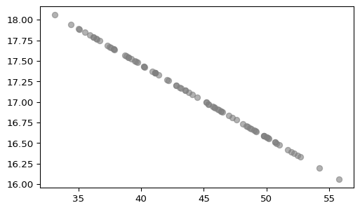

```python
plt.scatter(X_test, y_pred_lin, color="gray", alpha=0.6, label="Data")
plt.show()
```

# Cleaning Data For Quadratic

```python
df = df.dropna(subset=["bill_length_mm", "bill_depth_mm"])

y = df['bill_depth_mm']
X = df[['bill_length_mm']]

X.columns = ["x"]
X["x_sq"] = X["x"]**2
X["x_cube"] = X["x"]**3

X_train, X_test, y_train, y_test = train_test_split(X, y, test_size=0.25)
```

# Fitting Quadratic Model

```python
model_quad = LinearRegression()
model_quad_fitted = model_quad.fit(X_train[["x", "x_sq"]], y_train)

y_pred_quad = model_quad_fitted.predict(X_test[["x", "x_sq"]])
```

# Plotting Quadratic Model

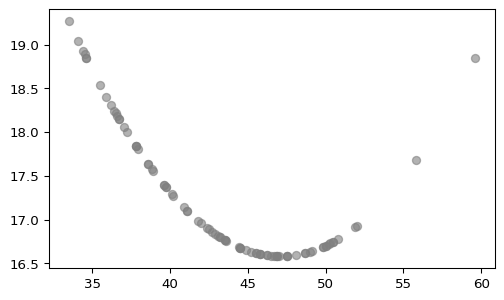

```python
plt.scatter(X_test["x"], y_pred_quad, color="gray", alpha=0.6, label="Data")
plt.show()
```

# Fitting Cubic Model

```python
model_cube= LinearRegression()
model_cube_fitted = model_cube.fit(X_train[["x", "x_sq", "x_cube"]], y_train)

y_pred_cube = model_cube_fitted.predict(X_test[["x", "x_sq", "x_cube"]])
```

# Plot Cubic Model

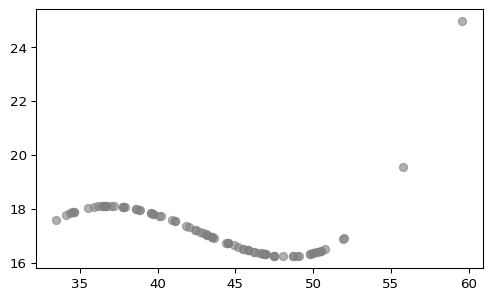

```python
plt.scatter(X_test["x"], y_pred_cube, color="gray", alpha=0.6, label="Data")
plt.show()
```

# Setup for 10 Degree Model

```python
df = df.dropna(subset=["bill_length_mm", "bill_depth_mm"])

y = df['bill_depth_mm']
X = df[['bill_length_mm']]

X.columns = ["x"]
X["x_sq"] = X["x"]**2
X["x_cube"] = X["x"]**3
X["x_four"] = X["x"]**4
X["x_five"] = X["x"]**5
X["x_six"] = X["x"]**6
X["x_seven"] = X["x"]**7
X["x_eight"] = X["x"]**8
X["x_nine"] = X["x"]**9
X["x_ten"] = X["x"]**10

X_train, X_test, y_train, y_test = train_test_split(X, y, test_size=0.25)
```

# 10 Degree Model

```python
model_ten = LinearRegression()
model_ten_fitted = model_ten.fit(X_train[["x", "x_sq", "x_cube", "x_four", "x_five", "x_six", "x_seven", "x_eight", "x_nine", "x_ten"]], y_train)

y_pred_ten = model_ten_fitted.predict(X_test[["x", "x_sq", "x_cube", "x_four", "x_five", "x_six", "x_seven", "x_eight", "x_nine", "x_ten"]])
```

# Plotting 10 degree model

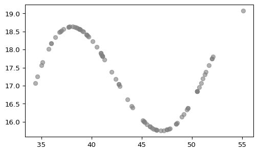

```python
plt.scatter(X_test["x"], y_pred_ten, color="gray", alpha=0.6, label="Data")
plt.show()
```

# Plotting X, y

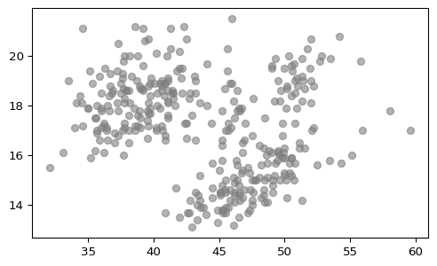

```python
plt.scatter(X['x'], y, color="gray", alpha=0.6, label="Data")
plt.show()
```

# Getting training data predictions

```python
y_train_pred_quad = model_quad_fitted.predict(X_train[["x", "x_sq"]])
y_train_pred_cube = model_cube_fitted.predict(X_train[["x", "x_sq", "x_cube"]])
y_train_pred_ten = model_ten_fitted.predict(X_train[["x", "x_sq", "x_cube", "x_four", "x_five", "x_six", "x_seven", "x_eight", "x_nine", "x_ten"]])
```

# RMSE Results

```python
rmse_lin_train = np.sqrt(mean_squared_error(y_train, y_train_pred_lin))
rmse_lin_test  = np.sqrt(mean_squared_error(y_test,  y_pred_lin))

rmse_quad_train = np.sqrt(mean_squared_error(y_train, y_train_pred_quad))
rmse_quad_test  = np.sqrt(mean_squared_error(y_test,  y_pred_quad))

rmse_cube_train = np.sqrt(mean_squared_error(y_train, y_train_pred_cube))
rmse_cube_test  = np.sqrt(mean_squared_error(y_test,  y_pred_cube))

rmse_ten_train = np.sqrt(mean_squared_error(y_train, y_train_pred_ten))
rmse_ten_test  = np.sqrt(mean_squared_error(y_test,  y_pred_ten))

print("Linear:  Train RMSE =", round(rmse_lin_train, 3),  "| Test RMSE =", round(rmse_lin_test, 3))
print("Quad:    Train RMSE =", round(rmse_quad_train, 3), "| Test RMSE =", round(rmse_quad_test, 3))
print("Cubic:   Train RMSE =", round(rmse_cube_train, 3), "| Test RMSE =", round(rmse_cube_test, 3))
print("Ten: Train RMSE =", round(rmse_ten_train, 3), "| Test RMSE =", round(rmse_ten_test, 3))
```

```
Linear:  Train RMSE = 1.992 | Test RMSE = 2.089
Quad:    Train RMSE = 1.858 | Test RMSE = 2.167
Cubic:   Train RMSE = 1.829 | Test RMSE = 2.227
Ten: Train RMSE = 1.648 | Test RMSE = 1.801
```

- Are any of the models above underfitting the data? If so, which ones and how can you tell?
- Are any of thhe models above overfitting the data? If so, which ones and how can you tell?
- Which of the above models do you think fits the data best and why?

None of the models appear to be overfit, The 10 degree model has the lowest RMSE for the testing data which would not be true if it were overfit. The linear, quadratic, and cubic models may be under fit as their test RMSE values are all higher than the 10 degree model.